# Chi Squared Test

```r
library(haven)
library(mosaic)
library(pander)
library(tidyverse)
gss2021 <- read_sas("../../Data/gss2021.sas7bdat",
    NULL)
```

```r
mygss <- gss2021 %>%
  select(SEX, SEXORNT) %>%
  filter(
    SEXORNT %in% c(1,2)
  )
```

### Background

Every year, the [GSS Data Explorer](https://gssdataexplorer.norc.org/home) releases survey data regarding over 500 questions asked to thousands of people. Among these questions include that of sex and sexual orientation.

### Hypothesis

With this data, the question may be raised: Is sexual orientation associated with gender? Does one’s sex have a higher propensity for one sexual orientation? Let’s look into that:

$$H_0: \text{Sex is not associated with sexual orientation} \\
H_a: \text{Sex is associated with sexual orientation}$$

For this analysis we will have a significance value of $\alpha = 0.05$

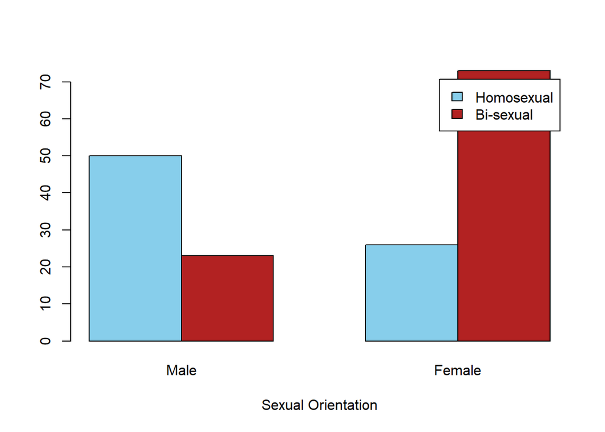

```r
mytable <- table(mygss$SEXORNT, mygss$SEX)

colnames(mytable) <- c("Male", "Female")
rownames(mytable) <- c("Homosexual", "Bi-sexual")

barplot(mytable, beside=TRUE, col=c('skyblue', 'firebrick'), legend.text= TRUE, xlab="Sexual Orientation")
```

```r
mytest <- chisq.test(mytable)

mytest$observed %>%
  pander(caption="Observed Values")
```

Observed Values

|  | Male | Female |
| --- | --- | --- |
| **Homosexual** | 50 | 26 |
| **Bi-sexual** | 23 | 73 |

We can see already that there is quite a difference in the data. What we would expect to see, if these two factors were not associated, is each sexual orientation having data of equal proportions: For example, since we see there being twice as many males who are homosexual, we would expect to see that same trend in the bi-sexual category with twice as many males again. Running a chi-squared test predicts the following values based on if these factors aren’t associated:

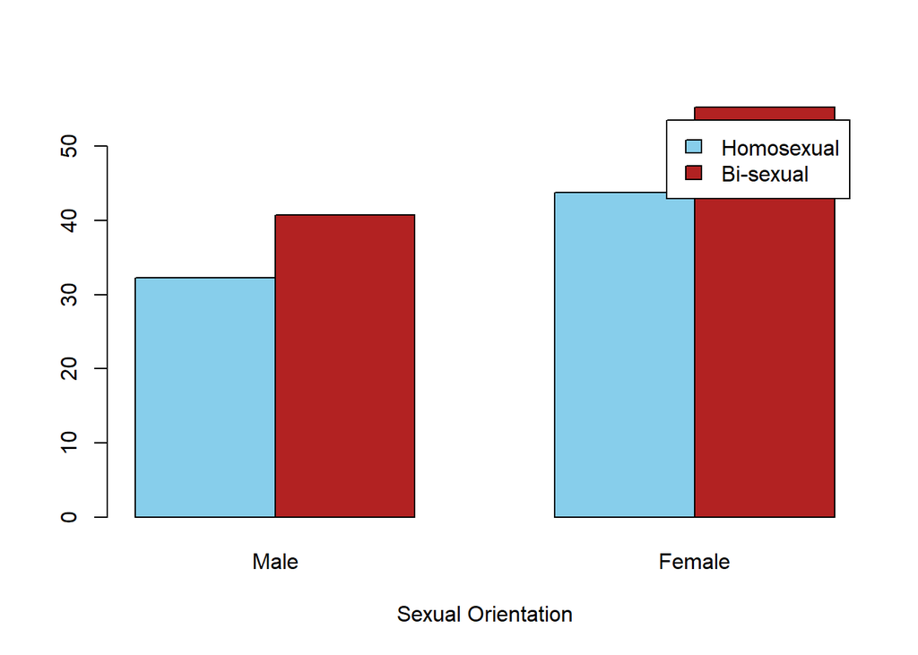

```r
barplot(mytest$expected, beside=TRUE, col=c('skyblue', 'firebrick'), legend.text= TRUE, xlab="Sexual Orientation")
```

```r
mytest %>%
  pander(caption="Chi-squared Test")
```

Chi-squared Test

| Test statistic | df | P value |
| --- | --- | --- |
| 28.7 | 1 | 8.466e-08 * * * |

```r
mytest$expected %>%
  pander(caption="Expected Values")
```

Expected Values

|  | Male | Female |
| --- | --- | --- |
| **Homosexual** | 32.26 | 43.74 |
| **Bi-sexual** | 40.74 | 55.26 |

We see in the expected values that similarly proportioned data mentioned earlier; however, our data is far from it. We expect the Homosexual/Bisexual ratio for each gender to be roughly .8, but we observed males to have a ratio of over two (50/23), and females to have a ratio of about .36 These results show a very significant trend here, resulting in a p-value of $p=8.466\text{e-}08$, which is significantly smaller than our $\alpha=0.05$.

```r
mytest$residuals %>%
  pander(caption="Residuals")
```

Residuals

|  | Male | Female |
| --- | --- | --- |
| **Homosexual** | 3.124 | -2.683 |
| **Bi-sexual** | -2.78 | 2.387 |

Using our residuals, we can calculate the percentage changes between our expected and observed results:

```r
perchange <- mytest$residuals * 1/sqrt(mytest$expected) *100

perchange %>%
  pander(caption="Percentage Changes from Expected")
```

Percentage Changes from Expected

|  | Male | Female |
| --- | --- | --- |
| **Homosexual** | 55.01 | -40.56 |
| **Bi-sexual** | -43.55 | 32.11 |

## Conclusion

There is sufficient evidence to reject our null hypothesis, and conclude that there is an association between ones sex and sexual orientation. We see that we observed there to be 55% more homosexual men than we expected and 32% more women who are bisexual than we expected. We also see a decrease of roughly 40% for bisexual men and homosexual women than expected. This conclusion is very intriguing, and there doesn’t appear to be a clear answer for the results we are seeing; however, this observation should spark many more questions for studies to be based on: What is causing this association? Do we see this association throughout history, or is it only recently? Has the association changed over time?